# Bay Wheels In August 2020 Exploration

## by Muhammad Elgendi

### Preliminary Wrangling

Bay Wheels is a regional public bicycle sharing system in California's San Francisco Bay Area. Bay Wheels is the first regional and large-scale bicycle sharing system deployed in California and on the West Coast of the United States. This dataset was collected from trips in august 2020 and it has 152446 records.

Each trip has the following features:

- Ride ID
- Bike type
- Start Time and Date
- End Time and Date
- Start Station Name
- Start Station ID
- End Station Name
- End Station ID
- Start Station Latitude
- Start Station Longitude
- End Station Latitude
- End Station Longitude
- User Type (Subscriber or Customer – “Subscriber” = Member or “Customer” = Casual)

```python
# import packages
import numpy as np
import pandas as pd
import matplotlib.pyplot as plt
import seaborn as sb

# set plots to be embedded inline
%matplotlib inline
```

```python
# read in the dataset
aug20 = pd.read_csv('202008-baywheels-tripdata.csv')
aug20.head()
```

|  | ride_id | rideable_type | started_at | ended_at | start_station_name | start_station_id | end_station_name | end_station_id | start_lat | start_lng | end_lat | end_lng | member_casual |
| --- | --- | --- | --- | --- | --- | --- | --- | --- | --- | --- | --- | --- | --- |
| 0 | 6549E11C13124B5F | electric_bike | 2020-08-14 09:41:03 | 2020-08-14 10:03:45 | NaN | NaN | Illinois St at 20th St | 376.0 | 37.790000 | -122.420000 | 37.760320 | -122.387456 | casual |
| 1 | B7F273BF69C8E4A3 | electric_bike | 2020-08-13 18:43:00 | 2020-08-13 18:52:52 | NaN | NaN | 24th St at Chattanooga St | 132.0 | 37.750000 | -122.410000 | 37.751798 | -122.426539 | casual |
| 2 | 33B224625CF1BC63 | electric_bike | 2020-08-14 09:13:54 | 2020-08-14 09:20:29 | 23rd St at Tennessee St | 355.0 | Jackson Playground | 115.0 | 37.755426 | -122.388588 | 37.764950 | -122.398857 | casual |
| 3 | 053D5F7D1AC11423 | electric_bike | 2020-08-14 11:26:54 | 2020-08-14 11:29:17 | Broderick St at Oak St | 71.0 | Pierce St at Haight St | 73.0 | 37.773053 | -122.439103 | 37.771924 | -122.433821 | casual |
| 4 | B3BDECA79FF1C671 | electric_bike | 2020-08-14 08:37:37 | 2020-08-14 08:52:20 | Broderick St at Oak St | 71.0 | NaN | NaN | 37.773232 | -122.439135 | 37.770000 | -122.490000 | casual |

```python
# let's take alook at how clean the dataset is ?
aug20.info()
```

```
<class 'pandas.core.frame.DataFrame'>
RangeIndex: 152446 entries, 0 to 152445
Data columns (total 13 columns):
 #   Column              Non-Null Count   Dtype
---  ------              --------------   -----
 0   ride_id             152446 non-null  object
 1   rideable_type       152446 non-null  object
 2   started_at          152446 non-null  object
 3   ended_at            152446 non-null  object
 4   start_station_name  104206 non-null  object
 5   start_station_id    104206 non-null  float64
 6   end_station_name    101349 non-null  object
 7   end_station_id      101349 non-null  float64
 8   start_lat           152446 non-null  float64
 9   start_lng           152446 non-null  float64
 10  end_lat             152246 non-null  float64
 11  end_lng             152246 non-null  float64
 12  member_casual       152446 non-null  object
dtypes: float64(6), object(7)
memory usage: 15.1+ MB
```

We have data for 152446 trips in august. I find the following features have missing data:

- start_station_name
- start_station_id
- end_station_name
- end_station_id
- end_lat
- end_lng

```python
# missing data rows count
aug20.isnull().sum()
```

```
ride_id                   0
rideable_type             0
started_at                0
ended_at                  0
start_station_name    48240
start_station_id      48240
end_station_name      51097
end_station_id        51097
start_lat                 0
start_lng                 0
end_lat                 200
end_lng                 200
member_casual             0
dtype: int64
```

```python
# check for duplicated data
aug20.duplicated().sum()
```

```
0
```

There is no duplicated rows in this dataset

```python
# explore rideable_type
aug20['rideable_type'].value_counts()
```

```
electric_bike    104200
docked_bike       48246
Name: rideable_type, dtype: int64
```

```python
# explore values for member_casual
aug20.member_casual.value_counts()
```

```
casual    90548
member    61898
Name: member_casual, dtype: int64
```

```python
# explore values for stations names
aug20.start_station_name.value_counts()
```

```
Market St at 10th St                            1545
Fell St at Stanyan St                           1215
Powell St BART Station (Market St at 4th St)    1158
Hyde St at Post St                              1057
Mission Dolores Park                             998
                                                ...
Foothill Blvd at Fruitvale Ave                     6
Foothill Blvd at Harrington Ave                    5
Webster St at 19th St                              2
4th Ave at E 12th St (Temporary Location)          2
10th Ave at E 15th St                              1
Name: start_station_name, Length: 449, dtype: int64
```

```python
aug20.end_station_name.value_counts()
```

```
Market St at 10th St                            1492
Powell St BART Station (Market St at 4th St)    1272
Fell St at Stanyan St                           1199
Mission Dolores Park                            1113
4th St at Mission Bay Blvd S                    1069
                                                ...
Bond St at High St                                 3
10th Ave at E 15th St                              2
32nd St at Adeline St                              2
Marston Campbell Park                              1
16th Depot Bike Fleet Station                      1
Name: end_station_name, Length: 455, dtype: int64
```

# Data cleaning

Since I won't conduct any spatial analysis, I will delete Latitude and Longitude variables

```python
# remove unuseful colums
aug20.drop(['start_lat','start_lng','end_lat','end_lng'],axis=1,inplace=True)
```

### Dealing with missing data

After removing the Latitude and Longitude variables, all missing data are in station_name and stating_id variables and because of missing values for these variables are around 33% of the dataset, I choose to keep these records despite the observed issue.

```python
# convert features to the correct type

# convert rideable_type to catagory variable
aug20['rideable_type'] = aug20['rideable_type'].astype('category')
# convert started_at to datetime variable
aug20['started_at'] = pd.to_datetime(aug20['started_at'])
# convert ended_at to datetime variable
aug20['ended_at'] = pd.to_datetime(aug20['ended_at'])
# convert start_station_id to string variable
aug20['start_station_id'] = aug20['start_station_id'].astype('str')
# convert end_station_id to string variable
aug20['end_station_id'] = aug20['end_station_id'].astype('str')

aug20.info()
```

```
<class 'pandas.core.frame.DataFrame'>
RangeIndex: 152446 entries, 0 to 152445
Data columns (total 9 columns):
 #   Column              Non-Null Count   Dtype
---  ------              --------------   -----
 0   ride_id             152446 non-null  object
 1   rideable_type       152446 non-null  category
 2   started_at          152446 non-null  datetime64[ns]
 3   ended_at            152446 non-null  datetime64[ns]
 4   start_station_name  104206 non-null  object
 5   start_station_id    152446 non-null  object
 6   end_station_name    101349 non-null  object
 7   end_station_id      152446 non-null  object
 8   member_casual       152446 non-null  object
dtypes: category(1), datetime64[ns](2), object(6)
memory usage: 9.5+ MB
```

```python
aug20.describe()
```

|  | ride_id | rideable_type | started_at | ended_at | start_station_name | start_station_id | end_station_name | end_station_id | member_casual |
| --- | --- | --- | --- | --- | --- | --- | --- | --- | --- |
| count | 152446 | 152446 | 152446 | 152446 | 104206 | 152446 | 101349 | 152446 | 152446 |
| unique | 152446 | 2 | 145308 | 145210 | 449 | 450 | 455 | 456 | 2 |
| top | F9EED125A97E9354 | electric_bike | 2020-08-17 18:20:54 | 2020-08-16 15:05:49 | Market St at 10th St | nan | Market St at 10th St | nan | casual |
| freq | 1 | 104200 | 4 | 5 | 1545 | 48240 | 1492 | 51097 | 90548 |
| first | NaN | NaN | 2020-08-01 00:00:13 | 2020-08-01 00:08:38 | NaN | NaN | NaN | NaN | NaN |
| last | NaN | NaN | 2020-08-31 23:57:21 | 2020-09-03 19:45:41 | NaN | NaN | NaN | NaN | NaN |

## Interesting note

Timestamps variables can not be used as primary key for this data since there are trips that starts or ends in the exact same timestamp.

```python
# feature engineering
# add new variables for trip duration, start_date, start_hour, and start_day to the dataset

# calculate difference between timestamps in seconds
aug20['duration_sec'] = (aug20['ended_at'] - aug20['started_at']).dt.total_seconds()

# calculate difference between timestamps in minutes
aug20['duration_min'] = aug20['duration_sec'] / 60

# add date in format year - month - day
aug20['start_date'] = aug20['started_at'].dt.strftime('%Y-%m-%d')

# add hour of the day
aug20['start_hour'] = aug20['started_at'].dt.strftime('%H')

# add weekday
aug20['start_day'] = aug20['started_at'].dt.strftime('%A')

# show changes
aug20.head()
```

|  | ride_id | rideable_type | started_at | ended_at | start_station_name | start_station_id | end_station_name | end_station_id | member_casual | duration_sec | duration_min | start_date | start_hour | start_day |
| --- | --- | --- | --- | --- | --- | --- | --- | --- | --- | --- | --- | --- | --- | --- |
| 0 | 6549E11C13124B5F | electric_bike | 2020-08-14 09:41:03 | 2020-08-14 10:03:45 | NaN | nan | Illinois St at 20th St | 376.0 | casual | 1362.0 | 22.700000 | 2020-08-14 | 09 | Friday |
| 1 | B7F273BF69C8E4A3 | electric_bike | 2020-08-13 18:43:00 | 2020-08-13 18:52:52 | NaN | nan | 24th St at Chattanooga St | 132.0 | casual | 592.0 | 9.866667 | 2020-08-13 | 18 | Thursday |
| 2 | 33B224625CF1BC63 | electric_bike | 2020-08-14 09:13:54 | 2020-08-14 09:20:29 | 23rd St at Tennessee St | 355.0 | Jackson Playground | 115.0 | casual | 395.0 | 6.583333 | 2020-08-14 | 09 | Friday |
| 3 | 053D5F7D1AC11423 | electric_bike | 2020-08-14 11:26:54 | 2020-08-14 11:29:17 | Broderick St at Oak St | 71.0 | Pierce St at Haight St | 73.0 | casual | 143.0 | 2.383333 | 2020-08-14 | 11 | Friday |
| 4 | B3BDECA79FF1C671 | electric_bike | 2020-08-14 08:37:37 | 2020-08-14 08:52:20 | Broderick St at Oak St | 71.0 | NaN | nan | casual | 883.0 | 14.716667 | 2020-08-14 | 08 | Friday |

```python
aug20.describe()
```

|  | duration_sec | duration_min |
| --- | --- | --- |
| count | 1.524460e+05 | 152446.000000 |
| mean | 1.550566e+03 | 25.842768 |
| std | 2.028845e+04 | 338.140773 |
| min | -3.470000e+02 | -5.783333 |
| 25% | 4.290000e+02 | 7.150000 |
| 50% | 7.540000e+02 | 12.566667 |
| 75% | 1.308000e+03 | 21.800000 |
| max | 2.666199e+06 | 44436.650000 |

```python
# show trips that have duration < 0 !
aug20[aug20['duration_sec'] < 0].shape
```

```
(45, 14)
```

There are 45 records with duration of less than zero which don't make sense. let's investigate this further.

```python
aug20[aug20['duration_sec'] < 0].head()
```

|  | ride_id | rideable_type | started_at | ended_at | start_station_name | start_station_id | end_station_name | end_station_id | member_casual | duration_sec | duration_min | start_date | start_hour | start_day |
| --- | --- | --- | --- | --- | --- | --- | --- | --- | --- | --- | --- | --- | --- | --- |
| 68670 | DBD7E8C90FD23C3F | docked_bike | 2020-08-26 09:22:37 | 2020-08-26 09:22:02 | 38th Ave at Balboa St | 532.0 | 48th Ave at Cabrillo St | 521.0 | member | -35.0 | -0.583333 | 2020-08-26 | 09 | Wednesday |
| 69492 | 3AA45B7F4E046B64 | docked_bike | 2020-08-25 18:10:19 | 2020-08-25 18:10:16 | Union Square (Powell St at Post St) | 324.0 | Townsend St at 5th St | 80.0 | member | -3.0 | -0.050000 | 2020-08-25 | 18 | Tuesday |
| 70593 | 2F643D51850121C3 | docked_bike | 2020-08-24 21:14:27 | 2020-08-24 21:13:45 | 21st Ave at Geary Blvd | 525.0 | 21st Ave at Geary Blvd | 525.0 | casual | -42.0 | -0.700000 | 2020-08-24 | 21 | Monday |
| 71699 | 2739F8321B9FB4F5 | docked_bike | 2020-08-19 17:51:09 | 2020-08-19 17:50:35 | Berry St at 4th St | 81.0 | Market St at Steuart St | 16.0 | casual | -34.0 | -0.566667 | 2020-08-19 | 17 | Wednesday |
| 71723 | BBAB0BCA7A97DFFB | docked_bike | 2020-08-06 17:41:00 | 2020-08-06 17:40:47 | Terry Francois Blvd at Mission Bay Blvd N | 461.0 | Beale St at Harrison St | 27.0 | member | -13.0 | -0.216667 | 2020-08-06 | 17 | Thursday |

```python
# show summary statistics
aug20[aug20['duration_sec'] < 0]['duration_min'].describe()
```

```
count    45.000000
mean     -0.615185
std       1.094747
min      -5.783333
25%      -0.583333
50%      -0.233333
75%      -0.083333
max      -0.016667
Name: duration_min, dtype: float64
```

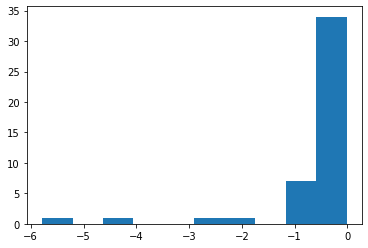

```python
plt.hist(aug20[aug20['duration_sec'] < 0]['duration_min']);
```

I assumed that started_at values and ended_at values were switched for these records, But apparently, this is not the case here since most of these records have a duration of less than a minute which suggests these records are false and must be removed.

```python
# remove trips that have duration < 0
aug20.drop(aug20[aug20['duration_sec'] < 0].index,axis=0,inplace=True)
```

```python
# check if changes are made correctly
aug20[aug20['duration_sec'] < 0].shape
```

```
(0, 14)
```

### What is the structure of your dataset?

The original dataset has 13 variables and around 150000 records. These variables can be catagorized into :

1. Bike info : ride_id and rideable_type
2. trip time : started_at and ended_at
3. station info : start_station_name, start_station_id, end_station_id, end_station_name, start_lat, start_lng, end_lat and ent_lng.
4. user info : member_casual variable

I drived other feature from trip time variables for analysis:

1. duration_sec (trip duration in seconds)
2. duration_min (trip duration in minutes)
3. start_date
4. start_hour
5. start_day

### What is/are the main feature(s) of interest in your dataset?

started_at, ended_at and member_casual variables

### What features in the dataset do you think will help support your investigation into your feature(s) of interest?

started_at, ended_at and all drived variables will help me understand the usage patern in terms of time and questions like :

- When are most trips taken in terms of time of day, day of the week?
- How long trip take in average ?
- Does the above depend on if a user is a subscriber or customer?
- Does user type has any relation with rideable type ?

## Univariate Exploration

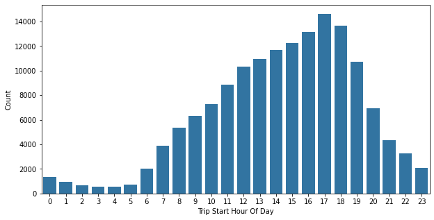

```python
# issue: convert start_hour to int
aug20['start_hour'] = aug20['start_hour'].astype('int')

# When are most trips taken in terms of time of day ?
plt.figure(figsize=(10,5))
sb.countplot(data = aug20,x = 'start_hour',color=sb.color_palette()[0])
plt.xlabel('Trip Start Hour Of Day')
plt.ylabel('Count');
```

From 5 AM to 5 PM the trend of trips is increasing and after that it starts to decrease.

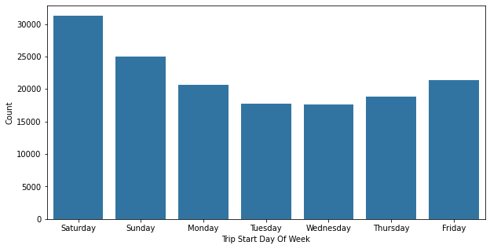

```python
# issue : convert start_day to ordinal category
days = ['Saturday','Sunday','Monday','Tuesday','Wednesday','Thursday','Friday']
weekday_type = pd.api.types.CategoricalDtype(days,True)
aug20['start_day'] = aug20['start_day'].astype(weekday_type)

# When are most trips taken in terms of day of the week ?
plt.figure(figsize=(10,5))
sb.countplot(data = aug20,x = 'start_day',color=sb.color_palette()[0])
plt.xlabel('Trip Start Day Of Week')
plt.ylabel('Count');
```

Trips demand increasing starting from Thursday until it reaches the highest demand on Saturday then the trend will start to decrease again.

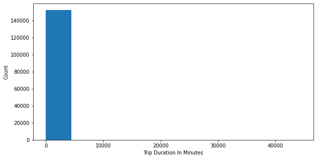

```python
# How long trips take ?
plt.figure(figsize=(10,5))
plt.hist(aug20['duration_min'])
plt.xlabel('Trip Duration In Minutes')
plt.ylabel('Count');
```

```python
# since we have this extreme outlier let's get the 99th percentile of data
aug20['duration_min'].describe(percentiles=[0.99])
```

```
count    152401.000000
mean         25.850580
std         338.190385
min           0.000000
50%          12.566667
99%         113.733333
max       44436.650000
Name: duration_min, dtype: float64
```

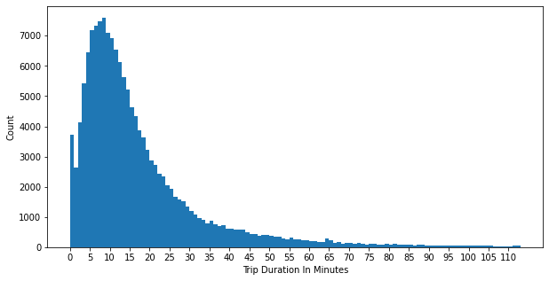

```python
# How long trips take ?
bins = np.arange(0,114,1)
ticks = np.arange(0,114,5)
plt.figure(figsize=(10,5))
plt.hist(aug20['duration_min'],bins=bins)
plt.xticks(ticks,ticks)
plt.xlabel('Trip Duration In Minutes')
plt.ylabel('Count');
```

99% of the trips in August have a duration of less than two hours. Most of the trips has a durations between 5 and 15 minutes.

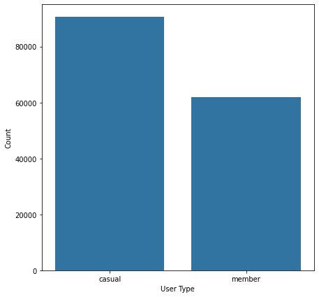

```python
# How much of the users are customers ?
plt.figure(figsize=(7,7))
sb.countplot(data = aug20,x = 'member_casual',color=sb.color_palette()[0])
plt.xlabel('User Type')
plt.ylabel('Count');
```

It looks that “Customer” type is more frequent than “Subscriber” type – “Subscriber” = Member and “Customer” = Casual.

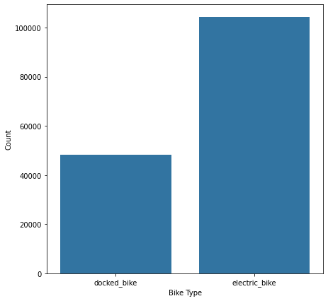

```python
# Types of bikes
plt.figure(figsize=(7,7))
sb.countplot(data = aug20,x = 'rideable_type',color=sb.color_palette()[0])
plt.xlabel('Bike Type')
plt.ylabel('Count');
```

Sounds that most of the users are using electric bike rather than docked bike.

### Discuss the distribution(s) of your variable(s) of interest. Were there any unusual points? Did you need to perform any transformations?

Most of the trips were short with durations between 5 and 15 minutes. The demand for trips has a peak at 5 PM and the trend is increasing from 5 AM reach the peak. From days perspective, the demand was increasing starting from Thursday until it reaches the highest demand on Saturday. Lastly, 99% of the trips in August have a duration of fewer than two hours with electric bikes were used the most.

No transformation was conducted luckily to the straightforwardness of data.

### Of the features you investigated, were there any unusual distributions? Did you perform any operations on the data to tidy, adjust, or change the form of the data? If so, why did you do this?

The distributions of features were usual, only changed the bin size and width to visualize trips durations in minutes. Also, I converted start_day to an ordinal category to imply the order of weekdays. Also, converted start_hour to int to order the hours of the day.

## Bivariate Exploration

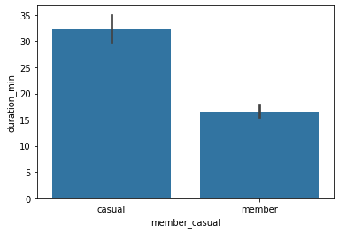

```python
# what is the relation between user type and the average trip duration ?
sb.barplot(data = aug20, x = 'member_casual', y = 'duration_min',color=sb.color_palette()[0]);
```

Subscribers tend to have shorter trips on average of 15 minutes, on the other hand, customers tend to have longer trips with a mean of around 32 minutes.

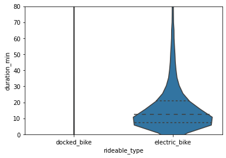

```python
# Is there any relation between bike type and trip duration ?
sb.violinplot(data = aug20, x = 'rideable_type', y = 'duration_min',color=sb.color_palette()[0],inner='quartile');
plt.ylim(0,80);
```

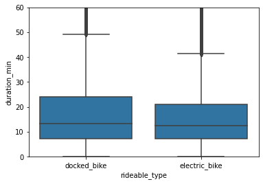

```python
sb.boxplot(data = aug20, x = 'rideable_type', y = 'duration_min',color=sb.color_palette()[0]);
plt.ylim(0,60);
```

Both types of bikes have roughly the same trip duration on average, but the third quartile of docked_bike in terms of trip duration is a bit higher.

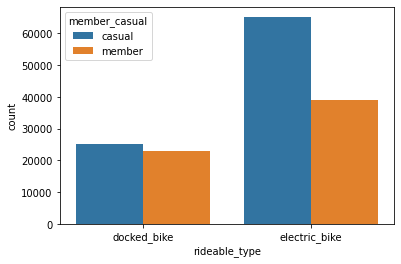

```python
# rideable type vs user type
sb.countplot(data = aug20, x = 'rideable_type', hue = 'member_casual');
```

Docked bikes are used roughly equally but customers use electric bikes the most.

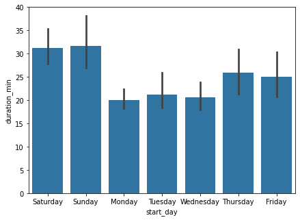

```python
# average trip durations on Week
plt.figure(figsize=(7,5))
sb.barplot(data = aug20, x = 'start_day', y = 'duration_min',color=sb.color_palette()[0]);
```

Weekends have longer trips on average, but weekdays have shorter trips.

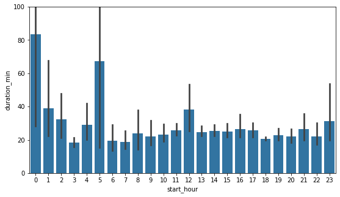

```python
# average trip durations over the day
plt.figure(figsize=(9,5))
sb.barplot(data = aug20, x = 'start_hour', y = 'duration_min',color=sb.color_palette()[0]);
plt.ylim(0,100);
```

Trips at 12 AM and 5 AM are longer than the others on average.

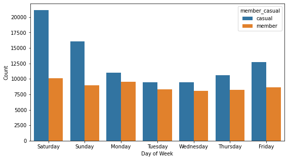

```python
# users usage over the week
plt.figure(figsize=(9,5))
sb.countplot(data=aug20, x='start_day', hue='member_casual');
plt.xlabel('Day of Week');
plt.ylabel('Count');
```

Customers use Bay Wheels the most on Saturday and Sunday, whereas, Subscribers use it the most on Saturday and Monday.

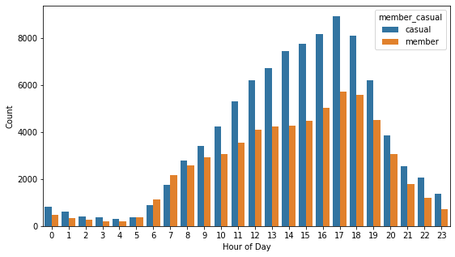

```python
# users usage over the day
plt.figure(figsize=(9,5))
sb.countplot(data=aug20, x='start_hour', hue='member_casual');
plt.xlabel('Hour of Day');
plt.ylabel('Count');
```

Trips over the day is roughly similar between the two types of users with a peak at 5 PM.

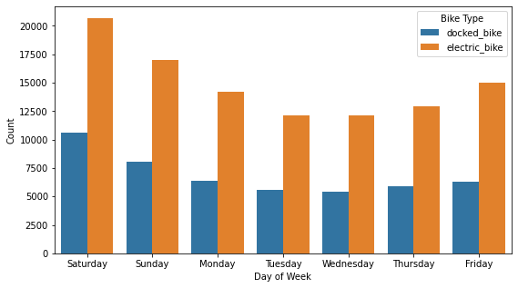

```python
# bike types over the week
plt.figure(figsize=(9,5))
sb.countplot(data=aug20, x='start_day', hue='rideable_type')
plt.xlabel('Day of Week')
plt.ylabel('Count')
plt.legend(title='Bike Type');
```

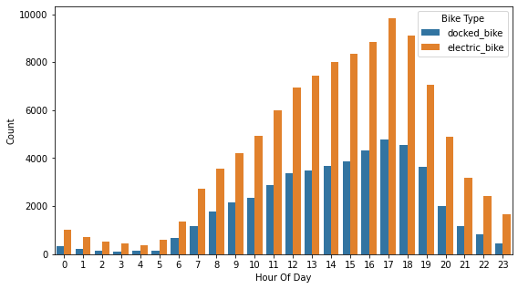

```python
# bike types over the day
plt.figure(figsize=(9,5))
sb.countplot(data=aug20, x='start_hour', hue='rideable_type')
plt.xlabel('Hour Of Day')
plt.ylabel('Count')
plt.legend(title='Bike Type');
```

Electric bikes are more than electric bikes, but the usage pattern of the two bike types over the week and the day are the same.

```python
# get top 10 used stations
stations = pd.concat([aug20['start_station_name'], aug20['end_station_name']])
top_stations = stations.value_counts()[:10].index
top_start_station_only = aug20[aug20['start_station_name'].isin(top_stations)]
```

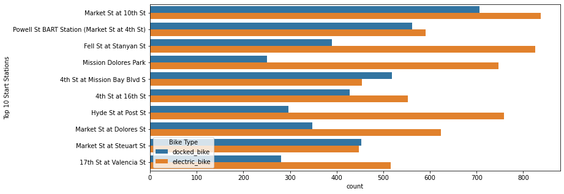

```python
# bike types in top used station that used as a start for the trip
plt.figure(figsize=(12,5))
sb.countplot(data=top_start_station_only, y='start_station_name', hue='rideable_type',order=top_stations)
plt.legend(loc=3,title="Bike Type")
plt.ylabel('Top 10 Start Stations');
```

All of the top ten start stations were stocked with electric bikes more than docked bikes, but 4th St at Mission Bay Blvd S and Market St at Steuart St have stocked with more docked bikes.

### Talk about some of the relationships you observed in this part of the investigation. How did the feature(s) of interest vary with other features in the dataset?

- Subscribers have shorter trips on average of 15 minutes, and customers have longer trips with a mean of around 32 minutes.
- Both types of bikes have roughly the same trip duration on average, but the third quartile of docked_bike in terms of trip duration is a bit higher.
- Docked bikes are used roughly equally but customers use electric bikes the most.
- Weekends have longer trips on average, but weekdays have shorter trips.
- Trips at 12 AM and 5 AM are longer than the others on average.
- Customers use Bay Wheels the most on Saturday and Sunday, whereas, subscribers use it the most on Saturday and Monday.
- Trips over the day is roughly similar between the two types of users with a peak at 5 PM.
- Electric bikes are more than electric bikes, but the usage pattern of the two bike types over the week and the day are the same.

### Did you observe any interesting relationships between the other features (not the main feature(s) of interest)?

All of the top ten start stations were stocked with electric bikes more than docked bikes, but 4th St at Mission Bay Blvd S and Market St at Steuart St have stocked with more docked bikes.

## Multivariate Exploration

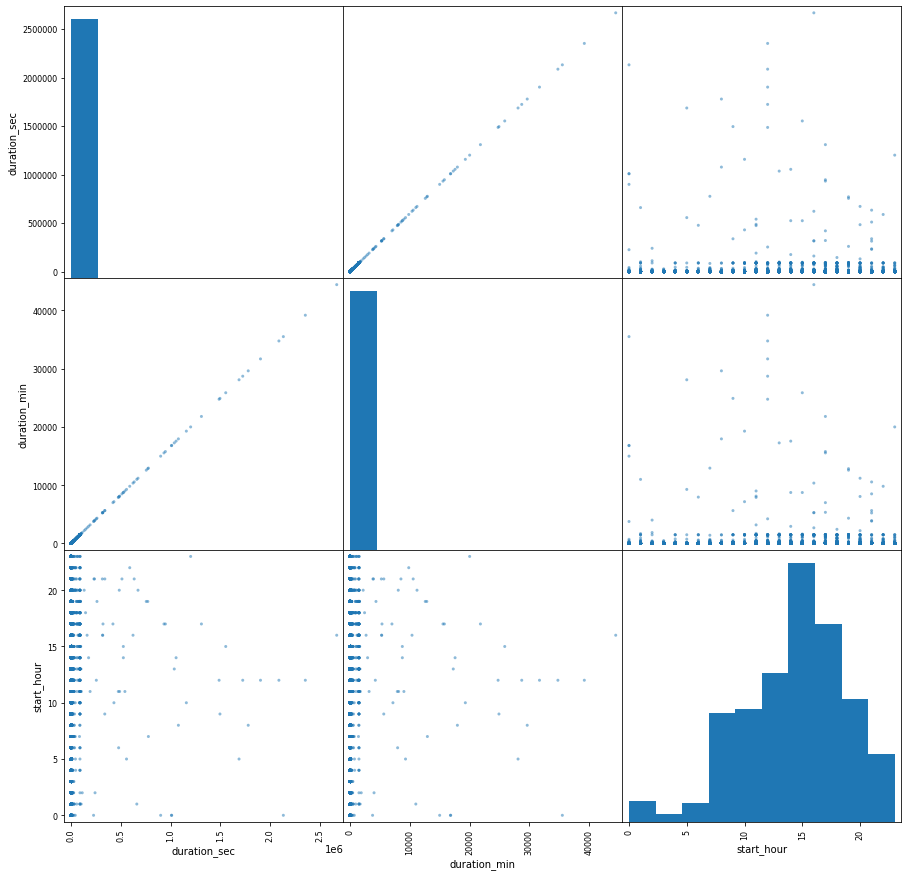

```python
# let's take an overview of relationships between variables (using a matrix of scatter plots)
pd.plotting.scatter_matrix(aug20,figsize=(15,15));
```

```python
# a look at the correlations
aug20.corr()
```

|  | duration_sec | duration_min | start_hour |
| --- | --- | --- | --- |
| duration_sec | 1.000000 | 1.000000 | -0.007718 |
| duration_min | 1.000000 | 1.000000 | -0.007718 |
| start_hour | -0.007718 | -0.007718 | 1.000000 |

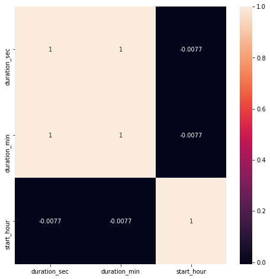

```python
plt.figure(figsize=(8,8))
sb.heatmap(aug20.corr(),annot=True);
```

The duration in minutes variable is driven from duration in seconds, thus the strong and positive relationship. We can observe a very weak and negative relation between duration in minutes and the "start hour" variable.

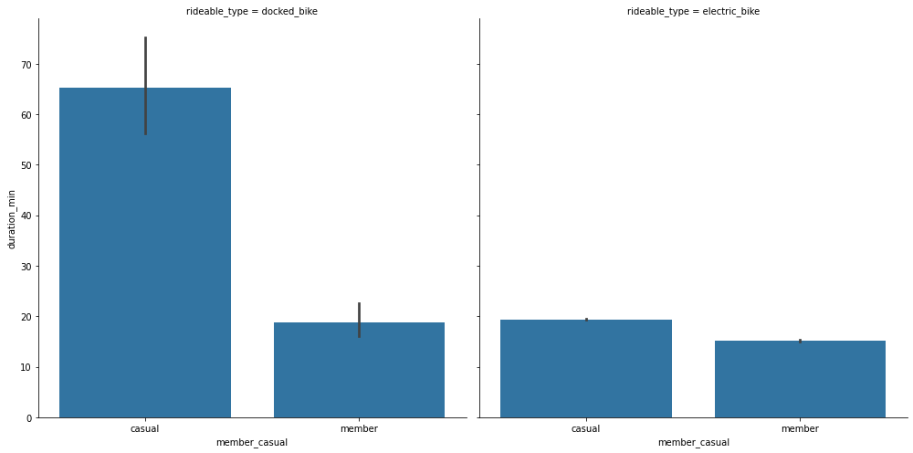

```python
# average trip duration of bike types and user types
g = sb.FacetGrid(data = aug20, col = 'rideable_type', height= 7)
g.map(sb.barplot, 'member_casual','duration_min',order=['casual','member']);
```

Of all Bay Wheels users, customers who used docked bikes have longer trips on average than all other users.

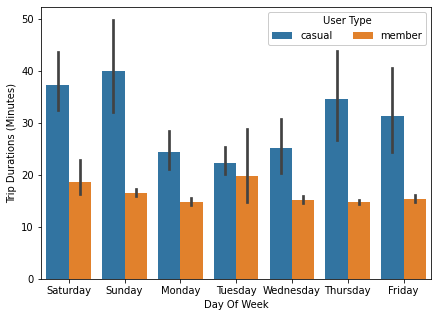

```python
# trip duration variation in the week between customers and subscribers
plt.figure(figsize=(7,5))
ax = sb.barplot(data = aug20, x = 'start_day', y = 'duration_min', hue = 'member_casual')
ax.legend(loc = 0, ncol = 3, framealpha = 1, title = 'User Type');
plt.xlabel('Day Of Week')
plt.ylabel('Trip Durations (Minutes)');
```

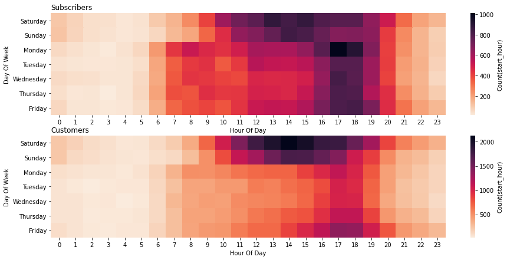

```python
# hourly usage during the week for customers and subscribers
plt.figure(figsize=(15,7))

# subscribers plot
plt.subplot(2, 1, 1)
subscriber_counts = aug20.query('member_casual == "member"').groupby(['start_day','start_hour']).size()
subscriber_counts = subscriber_counts.reset_index(name='count')
subscriber_counts = subscriber_counts.pivot(index='start_day',columns='start_hour',values='count')
# plot heatmap
sb.heatmap(subscriber_counts, cmap='rocket_r',cbar_kws = {'label' : 'Count(start_hour)'});
plt.xlabel('Hour Of Day')
plt.ylabel('Day Of Week')
plt.title('Subscribers', loc='left');

# customers plot
plt.subplot(2, 1, 2)
customer_counts = aug20.query('member_casual == "casual"').groupby(['start_day','start_hour']).size()
customer_counts = customer_counts.reset_index(name='count')
customer_counts = customer_counts.pivot(index='start_day',columns='start_hour',values='count')
# plot heatmap
sb.heatmap(customer_counts, cmap='rocket_r',cbar_kws = {'label' : 'Count(start_hour)'});
plt.xlabel('Hour Of Day')
plt.ylabel('Day Of Week')
plt.title('Customers', loc='left');
```

The pattern of usage is different between subscribers and customers.

For subscribers there exist an intense use over the whole week, their intense usage on Saturday is between 11 AM and 6 PM and on Sunday their usage is focused between 12 PM and 4 PM and for all other weekdays, the focused usage is between 5 PM and 6 PM.

For customers, their usage is intense on Saturday, Sunday, and Friday and light in the rest of the days. like subscribers, their usage on Saturday is between 11 AM and 6 PM But on Sunday their usage is focused between 1 PM and 5 PM, and for Friday there is an intense usage between 5 PM and 6 PM.

Most of the usage was observed between 5 PM and 6 PM for all users.

### Talk about some of the relationships you observed in this part of the investigation. Were there features that strengthened each other in terms of looking at your feature(s) of interest?

Multivariate exploration strengthened the findings that were obtained in univariate and bivariate exploration.

### Were there any interesting or surprising interactions between features?

I didn't find any surprising interactions between features. The observation of customers who used docked bikes having longer trips on average than all other users was a little bit surprising, and I think more features and data are needed for further investigation.